mHapTools

Installation Annotation Files Manual Test DataSets mHapDB Citation

# Test data sets

There is no existing tools to benchmark mHapTools, we have manually checked random regions to make sure our implementation is correct. In principle, CpG site methylation derived from BAM file should be highly correlated, if not identical, with that from mHap file. We thus tested concordance of mean methylation on three samples, which were sequenced as single-end or paired-end, and were processed by Bismark and Bsmap. The test datasets and associated results are available [here](http://bioinformatics.sibcb.ac.cn/dataupload/DataSets/DNAmethylation/). Fastq files for two samples (HUES64 and HCT116) were downloaded from GEO and processed in house. BAM and CpG bedMethylation files for Adrenal Gland were downloaded from ENCODE and processed by mHapTools.

## Data sets

[output not shown]

## Concordance

Using demo samples (HUES64 and HCT116), we have compared CGI-level mean methylation which were calculated by aligners and mHapTools. In general, good correlation is observed when reads were alinged by BSMAP and BISMARK.

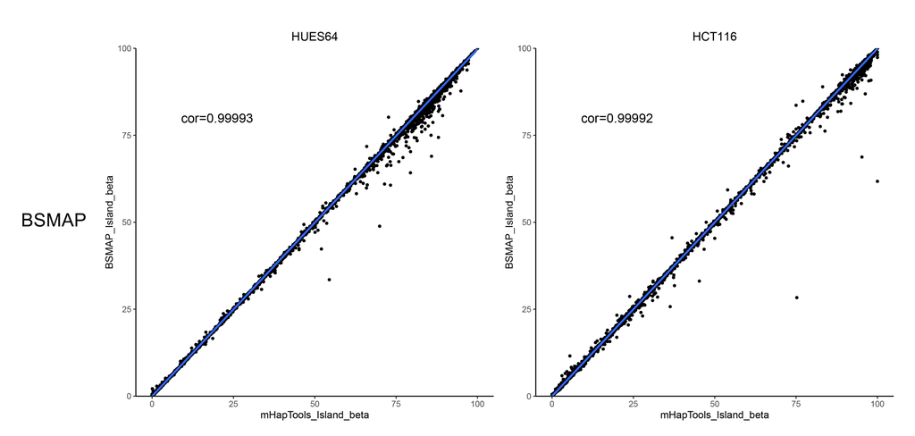

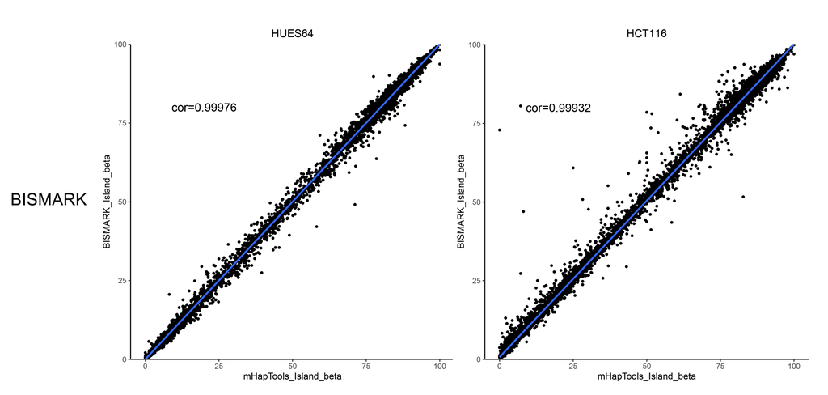

Shanghai Institute of Biochemistry and Cell Biology, Center for Excellence in Molecular Cell Science, CAS